# Algumas dicas sobre formas e medidas de correlação

Nazareno Andrade

13 de março de 2016

```r
require(ggplot2, quietly = TRUE)
require(GGally, quietly = TRUE)
require(reshape, quietly = TRUE)
require(dplyr, quietly = TRUE)
```

## Sobre forma e medida

Em análise exploratória, com frequência queremos examinar se há associação entre duas variáveis numéricas. Conselho importante: não há um número apenas que possa lhe responder tudo sobre a associação entre as duas variáveis. As medidas de correlação que você usará servirão mais para complementar e quantificar observações feitas em gráficos de dispersão do que para lhe guiar.

Um exemplo classico com quatro pares de variáveis cujas associações interessam: x1 e y1, x2 e y2, etc., o [quarteto de Anscombe](https://en.wikipedia.org/wiki/Anscombe%27s_quartet):

```r
summary(anscombe)
```

```
       x1             x2             x3             x4           y1               y2
 Min.   : 4.0   Min.   : 4.0   Min.   : 4.0   Min.   : 8   Min.   : 4.260   Min.   :3.100
 1st Qu.: 6.5   1st Qu.: 6.5   1st Qu.: 6.5   1st Qu.: 8   1st Qu.: 6.315   1st Qu.:6.695
 Median : 9.0   Median : 9.0   Median : 9.0   Median : 8   Median : 7.580   Median :8.140
 Mean   : 9.0   Mean   : 9.0   Mean   : 9.0   Mean   : 9   Mean   : 7.501   Mean   :7.501
 3rd Qu.:11.5   3rd Qu.:11.5   3rd Qu.:11.5   3rd Qu.: 8   3rd Qu.: 8.570   3rd Qu.:8.950
 Max.   :14.0   Max.   :14.0   Max.   :14.0   Max.   :19   Max.   :10.840   Max.   :9.260
       y3              y4
 Min.   : 5.39   Min.   : 5.250
 1st Qu.: 6.25   1st Qu.: 6.170
 Median : 7.11   Median : 7.040
 Mean   : 7.50   Mean   : 7.501
 3rd Qu.: 7.98   3rd Qu.: 8.190
 Max.   :12.74   Max.   :12.500
```

```r
# um pouco de rearrumação primeiro.
# (para entender melhor, você pode procurar sobre dados em formato
# wide ou long no R)
t1 <- melt(select(anscombe, 1:4), id = c())
t2 <- melt(select(anscombe, 5:8), id = c())
names(t2) <- c("v2", "value2")
dados <- data.frame(vars = paste(t1$variable, "e", t2$v2),
               v1 = t1$value,
               v2 = t2$value2)
```

Calculando a correlação linear:

```r
dados %>%
  group_by(vars) %>%
  summarise(correlacao = cor(v1, v2, method = "pearson"))
```

| vars | correlacao |
| --- | --- |
| x1 e y1 | 0.8164205 |
| x2 e y2 | 0.8162365 |
| x3 e y3 | 0.8162867 |
| x4 e y4 | 0.8165214 |

E se olharmos os dados?

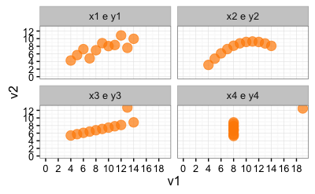

```r
ggplot(dados, aes(v1, v2)) +
  geom_point(color = "darkorange", size = 4, alpha = 0.7) +
  theme_bw() +
  scale_x_continuous(breaks = seq(0, 20, 2)) +
  scale_y_continuous(breaks = seq(0, 12, 2)) +
  expand_limits(x = 0, y = 0) +
  facet_wrap(~ vars)
```

Quatro relações diferentes, mesma quantificação. Para o segundo grupo, não há uma relação linear. No 3o, há uma relação perfeita entre a maioria das observações, com uma exceção. No 4o grupo não há relação; há uma exceção que faz parecer que há uma relação.

O que os outros coeficientes podem nos dizer?

```r
dados %>%
  group_by(vars) %>%
  summarise(pearson = cor(v1, v2, method = "pearson"),
            spearman = cor(v1, v2, method = "spearman"),
            kendall = cor(v1, v2, method = "kendall"))
```

[output not shown]

## Força e também direção

Dito isso, essa figura ajuda a lembrar a relação entre o valor esperado do coeficiente (linear) e vários tipos de associação entre duas variáveis:

[figure not shown]

da wikipedia

# Alguns testes gerando a relação

Relação linear:

```r
set.seed(123)
x <- rnorm(100) * 100
tamanho_do_erro <- 50
y <- 0.5 * x + rnorm(100) * tamanho_do_erro + 20

df <- data.frame(x = x,
                 y = y)

ggplot(df, aes(x = x, y = y)) +
  geom_point(colour = "darkgrey", size = 4) +
  theme_bw()

cor(df$x, df$y, method = "pearson")

# Dobro de erro em torno de uma função linear f(x)
df$y <- 0.5 * x + rnorm(100) * tamanho_do_erro * 2 + 20

ggplot(df, aes(x = x, y = y)) +
  geom_point(colour = "darkgrey", size = 4) +
  theme_bw()
cor(df$x, df$y, method = "pearson")
```

[output not shown]

Relação não linear

[figure not shown]

## Dica prática

Quando considerando várias variáveis, o mais prático é usar uma matriz de gráficos de dispersão:

```r
dados <- read.csv("dados//Dados de alunos para as aulas de FPCC-report.csv")
dados <- dados %>% select(2, 3, 5, 7, 9) %>% filter(complete.cases(dados))
names(dados) <- c("curso", "sexo", "repositorios", "confianca.em.estatistica",
                  "altura")

str(dados)

# require(GGally)
ggpairs(dados, params = c(binwidth = 2, alpha = 0.7))
```

[output not shown]

[figure not shown]

```r
ggpairs(dados)
```